# MLB Pitch Prediction

Using Machine Learning Models to Predict Pitch Type

Leonardo Guzman

PSTAT 131/231 Fall 2023

## Introduction

The main goal of this project is to build a machine learning model that can accurately predict the type of pitch that will be thrown.

[figure not shown]

### What do we mean by pitch type?

In a baseball game, the pitcher’s primary objective to get as many batters out as possible. To do this they use a variety of different techniques to throw a baseball and each technique causes the ball to behave a certain way. These pitch types are used to keep a batter guessing at what pitch they will receive. The decision of what pitch to throw depends on a number of different factors such as how many runners are on base, what the strike/ball count is, the number of outs and even on the known strengths/weaknesses of the specific batter!

### Why is this important?

At the MLB level, batters have less than half a second from the time the ball leaves the pitchers hand to when it reaches home plate so the less time they spend guessing at what pitch is coming the greater the chance they stand at getting a hit. Teams go to great lengths to achieve this and there is no clearer example than the Houston Astros cheating scandal where they stole the opposing team’s signs using cameras and they went on the win the 2017 MLB World Series! Cheating scandals aside, most batters guess the pitch type using their years of experience and we’ll be trying to build a model to try to mimic the skill of the best baseball players in the world.

## Exploratory Data Analysis

We will be using data from the Kaggle dataset [“MLB Statcast Data”](https://www.kaggle.com/datasets/s903124/mlb-statcast-data?select=Statcast_2021.csv). Before we conduct any modeling it is important to get familiar with the dataset and conduct some preprocessing so that we are using clean data to build our models.

### Loading and Exploring Raw Data

Our first step is to load our raw pitch type data

```r
raw_pitch_data = read.csv("/cloud/project/PSTAT 131 Final Project/data/Statcast_2021.csv")
```

Now that we’ve loaded our data we can go ahead and take a look at the predictors we have at our disposal

```r
raw_pitch_data %>% clean_names() %>% head()
```

|  | x | pitch_type | game_date | release_speed | release_pos_x | release_pos_z | player_name | batter | pitcher | events | description | spin_dir | spin_rate_deprecated | break_angle_deprecated | break_length_deprecated | zone | des | game_type | stand | p_throws | home_team | away_team | type | hit_location | bb_type | balls | strikes | game_year | pfx_x | … |
| --- | --- | --- | --- | --- | --- | --- | --- | --- | --- | --- | --- | --- | --- | --- | --- | --- | --- | --- | --- | --- | --- | --- | --- | --- | --- | --- | --- | --- | --- | --- |
| 1 | 2926 | FF | 2021-10-03 | 92.3 | 1.40 | 6.80 | Smith, Will | 596019 | 519293 | field_out | hit_into_play | NA | NA | NA | NA | 1 | Francisco Lindor grounds out, third baseman Ehire Adrianza to first baseman Austin Riley. | R | R | L | ATL | NYM | X | 5 | ground_ball | 1 | 2 | 2021 | 0.69 | … |
| 2 | 3048 | SL | 2021-10-03 | 80.6 | 1.60 | 6.64 | Smith, Will | 596019 | 519293 |  | foul | NA | NA | NA | NA | 4 | Francisco Lindor grounds out, third baseman Ehire Adrianza to first baseman Austin Riley. | R | R | L | ATL | NYM | S | NA |  | 1 | 1 | 2021 | -0.77 | … |
| 3 | 3294 | CU | 2021-10-03 | 75.5 | 1.46 | 6.88 | Smith, Will | 596019 | 519293 |  | foul | NA | NA | NA | NA | 5 | Francisco Lindor grounds out, third baseman Ehire Adrianza to first baseman Austin Riley. | R | R | L | ATL | NYM | S | NA |  | 1 | 0 | 2021 | -0.65 | … |
| 4 | 3447 | CU | 2021-10-03 | 75.0 | 1.53 | 6.83 | Smith, Will | 596019 | 519293 |  | ball | NA | NA | NA | NA | 12 | Francisco Lindor grounds out, third baseman Ehire Adrianza to first baseman Austin Riley. | R | R | L | ATL | NYM | B | NA |  | 0 | 0 | 2021 | -0.69 | … |
| 5 | 3545 | FF | 2021-10-03 | 91.2 | 1.49 | 6.66 | Smith, Will | 607043 | 519293 | field_out | hit_into_play | NA | NA | NA | NA | 4 | Brandon Nimmo grounds out, second baseman Ozzie Albies to first baseman Austin Riley. | R | L | L | ATL | NYM | X | 4 | ground_ball | 1 | 0 | 2021 | 0.63 | … |
| 6 | 3765 | FF | 2021-10-03 | 92.5 | 1.35 | 6.74 | Smith, Will | 607043 | 519293 |  | ball | NA | NA | NA | NA | 11 | Brandon Nimmo grounds out, second baseman Ozzie Albies to first baseman Austin Riley. | R | L | L | ATL | NYM | B | NA |  | 0 | 0 | 2021 | 0.54 | … |

Let’s also go ahead and look at the size of our dataset

```r
dim(raw_pitch_data)
```

```
## [1] 709851     93
```

The data contains 709,851 observations and 93 predictors! Considering that the dataset spans the entire 2021 MLB Season and one single MLB game can contain hundreds of pitches, we should not be surprised at the size of the data. Now we will check to see if there are any missing observations.

```r
raw_pitch_data %>% is.na() %>% colSums() %>% data.frame()
```

|  | . |
| --- | --- |
| X | 0 |
| pitch_type | 0 |
| game_date | 0 |
| release_speed | 401 |
| release_pos_x | 578 |
| release_pos_z | 578 |
| player_name | 0 |
| batter | 0 |
| pitcher | 0 |
| events | 0 |

[output cut: 83 more lines]

It looks like some variables have every single value missing, this is because those variables are deprecated metrics from an older tracking system called PITCHf/x (our dataset comes from PITCHf/x’s successor known as Statcast) and so we can drop these without worrying about how it will affect our data. We will also have to drop a number of other columns that have upwards of 400,000 missing observations but fortunately these were columns that I was already planning on dropping during the variable selection process. As far as the rest of the columns with missing values, our data set is so large that I feel comfortable that simply omitting the observations instead of dropping the column will not bias our dataset in any meaningful way.

### Tidying Data

```r
drop = c("spin_dir", "spin_rate_deprecated", "break_angle_deprecated",
         "break_length_deprecated", "tfs_deprecated", "tfs_zulu_deprecated",
         "umpire", "sv_id", "hit_location", "on_3b", "on_2b", "on_1b",
         "hc_x", "hc_y", "hit_distance_sc", "launch speed", "launch_angle",
         "estimated_ba_using_speedangle", "estimated_woba_using_speedanlge",
         "woba_value", "woba_denom", "babip_value", "iso_value", "launch_speed_angle")

raw_pitch_data = raw_pitch_data[ , !names(raw_pitch_data) %in% drop]

raw_pitch_data = raw_pitch_data %>% na.omit()

dim(raw_pitch_data)
```

```
## [1] 120886     71
```

Since the dataset is so large and I am heavily limited by the computing power of my outdated Macbook, I will pull a smaller sample to use for our models and I will be stratifying on `pitch type` to ensure that our data still tells the same story. To this end I have calculated the proportion of each pitch type from the raw data. I will do the same for the stratified sample and then compare them.

```r
raw_freq_df = raw_pitch_data %>% group_by(pitch_type) %>%
                                 summarise(Percentage = n() / nrow(raw_pitch_data) * 100)

raw_freq_df
```

| pitch_type | Percentage |
| --- | --- |
| CH | 1.313386e+01 |
| CS | 4.632464e-02 |
| CU | 6.971858e+00 |
| EP | 1.489006e-02 |
| FA | 1.629635e-01 |
| FC | 7.109177e+00 |
| FF | 3.340172e+01 |
| FS | 1.476598e+00 |
| KC | 1.591582e+00 |
| KN | 1.240838e-02 |

[output cut: 3 more lines]

Now that we have a reference for the respective proportion of pitch types, we can construct our sample by stratifying on `pitch_type`

```r
set.seed(386)

pitch = raw_pitch_data %>% group_by('pitch_type') %>%
                                sample_n(size = 2000)
```

Now we will calculate the percentage of each pitch in the stratified sample and compare them to the proportion of the raw data and it looks like we succeeded in creating a proportional sample. One thing to note is that some of the pitch types with extremely low representation in the raw data do not appear in the stratified sample. This data loss is not an issue since we will still be further reducing the number of pitch types we are trying to predict to only the most common.

```r
strat_freq_df = pitch %>% group_by(pitch_type) %>%
                               summarise(Percentage = n() / nrow(pitch) * 100)

freq_df = merge(raw_freq_df, strat_freq_df, by = "pitch_type")

freq_df
```

| pitch_type | Percentage.x | Percentage.y |
| --- | --- | --- |
| CH | 13.13386165 | 12.70 |
| CS | 0.04632464 | 0.15 |
| CU | 6.97185778 | 6.40 |
| FA | 0.16296345 | 0.10 |
| FC | 7.10917724 | 7.25 |
| FF | 33.40171732 | 33.90 |
| FS | 1.47659779 | 1.40 |
| KC | 1.59158215 | 1.40 |
| KN | 0.01240838 | 0.05 |
| SI | 18.18241980 | 18.35 |

[output cut: 1 more lines]

### Variable Selection

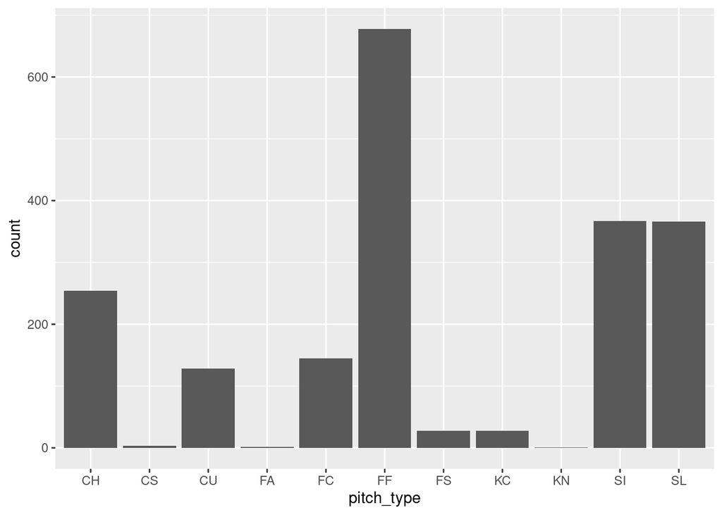

```r
ggplot(data = pitch, aes(x = pitch_type)) + geom_bar()
```

```r
pitch = filter(pitch, pitch_type %in% c('FF', 'SL', 'CH', 'CU', 'SI', 'FC'))

pitch = pitch %>% mutate(pitch_type = factor(pitch_type))
```

```r
pitch = subset(pitch, select = c("release_speed", "release_pos_x", "release_pos_y", "release_pos_z",
                                 "balls", "strikes", "pfx_x", "pfx_z", "plate_x", "plate_z",
                                 "vx0", "vy0", "vz0", "ax", "ay", "release_spin_rate",
                                 "spin_axis", "pitch_type"))

pitch %>% head()
```

| release_speed | release_pos_x | release_pos_y | release_pos_z | balls | strikes | pfx_x | pfx_z | plate_x | plate_z | vx0 | vy0 | vz0 | ax | ay | release_spin_rate | spin_axis | pitch_type |
| --- | --- | --- | --- | --- | --- | --- | --- | --- | --- | --- | --- | --- | --- | --- | --- | --- | --- |
| 95.7 | -1.45 | 53.65 | 6.70 | 3 | 2 | -0.40 | 1.36 | 0.18 | 3.91 | 5.2766210 | -139.4337 | -4.9473840 | -6.245158 | 27.14865 | 2423 | 204 | FF |
| 93.9 | -2.02 | 54.53 | 5.97 | 2 | 0 | -0.40 | 1.37 | 0.06 | 2.30 | 6.2317461 | -136.4862 | -6.7678751 | -6.384707 | 29.12906 | 2376 | 205 | FF |
| 83.4 | -1.86 | 54.43 | 5.03 | 1 | 2 | 1.22 | 0.02 | 0.50 | 1.93 | 3.0129212 | -121.4464 | -0.7320556 | 11.494844 | 23.48667 | 1939 | 56 | SL |
| 79.2 | 0.70 | 54.51 | 6.27 | 1 | 1 | 0.86 | 0.97 | 1.30 | 2.16 | -0.2738957 | -115.3841 | -4.0735527 | 7.773721 | 18.79700 | 1957 | 120 | CH |
| 92.3 | -1.77 | 54.35 | 5.41 | 2 | 2 | -0.39 | 1.12 | -0.09 | 2.38 | 5.1174152 | -134.4085 | -4.3674685 | -5.787131 | 25.24776 | 2361 | 218 | FF |
| 91.7 | -1.12 | 53.70 | 6.31 | 2 | 2 | -1.23 | 1.00 | 0.09 | 2.21 | 5.7698564 | -133.2587 | -6.6996740 | -15.932647 | 28.94047 | 2424 | 199 | SI |

Selecting which variables to keep out of the remaining 71 in the dataset was a fairly straightforward process since I played baseball for most of my life and so I’m very familiar with which variables will play a vital role in pitch recognition. The variables I chose are as follows:

- `release_speed`: Velocity of the ball out of the pitcher’s hand, measured in mph
- `release_pos_x`: Horizontal release position of the ball from the catcher’s perspective, measured in feet
- `release_pos_y`: Vertical release position of the ball from the catcher’s perspective, measured in feet
- `release_pos_z`: Release position of pitch measured in feet from catcher’s perspective
- `balls`: Number of balls in the count before pitch
- `strikes`: Number of strikes in the count before the pitch
- `pfx_x`: Horizontal movement in feet from the catcher’s perspective
- `pfx_z`: Vertical movement in feet from the catcher’s perspective
- `plate_x`: Horizontal position of the ball when it crosses home plate from the catcher’s perspective
- `plate_z`: Vertical position of the ball when it crosses home plate from the catcher’s perspective
- `vx0`: The velocity of the pitch in the x-dimension, determined at y = 50 feet and measured in ft/sec
- `vy0`: The velocity of the pitch in the y-dimension, determined at y = 50 feet and measured in ft/sec
- `vz0`: The velocity of the pitch in the z-dimension, determined at y = 50 feet and measured in ft/sec
- `ax`: The acceleration of the pitch in the x-dimension, determined at y = 50 feet and measured in ft/sec
- `ay`: The acceleration of the pitch in the y-dimension, determined at y = 50 feet and measured in ft/sec
- `release_spin_rate`: Spin rate of pitch tracked by Statcast
- `spin_axis`: The Spin Axis in the 2D X-Z plane in degrees from 0 to 360, such that 180 represents a pure backspin fastball and 0 degrees represents a pure topspin (12-6) curveball

*Note: To understand the orientation of the XYZ plane in this context imagine that you are standing on the pitcher’s mound. The X plane would extend sideways towards first and third base. The Y plane is a straight line between you and the catcher. The Z plane is a straight line from the ground to the sky.*

### Visual EDA

#### Correlation Matrix

Since all of our features are numerical, the first thing we are going to do is create a correlation matrix to get a better understanding of their relationship.

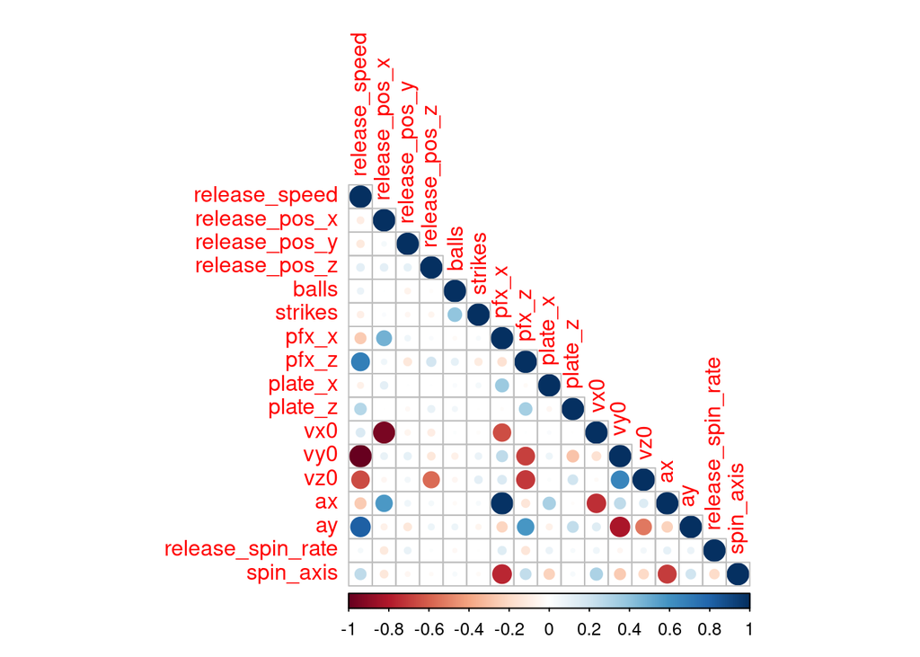

```r
pitch_numeric = pitch %>% select_if(is.numeric)

corrplot(cor(pitch_numeric, use = "pairwise.complete.obs"), type = 'lower', diag = TRUE)
```

It looks like we have a lot of strong correlations which is not too surprising considering that our chosen variables essentially encompass three areas:

- velocity/acceleration of the ball
- position of the ball in the xyz-plane
- rotational movement of the ball

#### Scatterplots

It’s pretty clear to see how these variables are all related to each other but let’s a look at a few interesting interactions which will give us a better understanding of how these pitches behave. The first is a scatter plot of `pfx_x` vs `ax` (refer to variable definitions above), notice how it is a positive linear relationship. This makes sense considering that a fastball which travels in a straight line will have very low acceleration in the x direction and therefore will also have very little movement in that direction. This gives us some possible insight into how the models might classify the pitches, any movement that deviates from a straight line path will most likely not be a fastball.

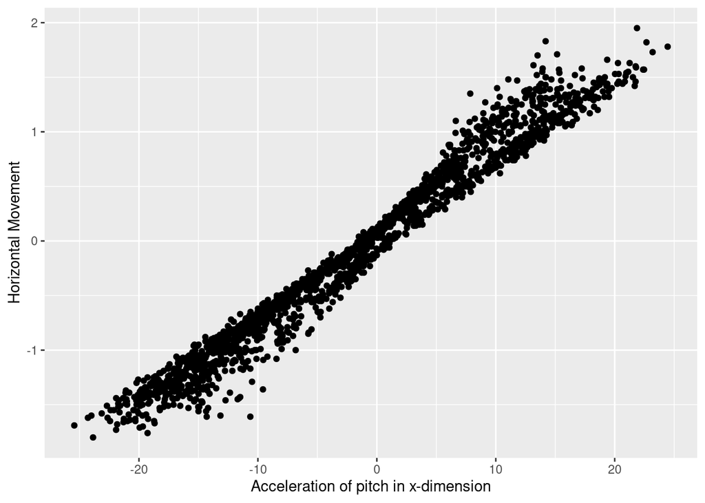

```r
ggplot(pitch, aes(x = ax, y = pfx_x)) +
  geom_point() +
  ylab("Horizontal Movement") +
  xlab("Acceleration of pitch in x-dimension")
```

The second is a scatterplot of `spin axis` vs `release speed`. Recall that a fastball lies at 180 degrees on the spin axis and that also happens to be where the release speed peaks. Now take a look at how a low value for spin axis and a high value for spin axis both have similar release speeds. It seems that predicting a fastball will be a fairly straightforward process. Classifying offspeed pitches (anything that isn’t a fastball) looks like it will be a trickier process but this graph gives us some insight that spin axis might play a valuable role.

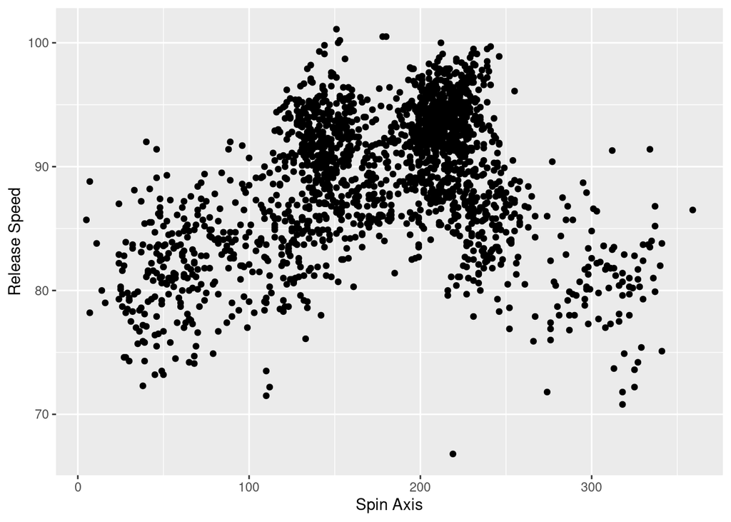

```r
ggplot(pitch, aes(x = spin_axis, y = release_speed)) +
  geom_point() +
  xlab("Spin Axis") +
  ylab("Release Speed")
```

## Setting up Models

Now that we have a better understanding of our variables we can finally move on to building our models!

### Train/Test Split

The first step we need to take before building our models is to split our data into training and testing samples. The training sample, as you may have guessed from the name, is used to train the model. Likewise, once the models are built the testing sample will be used to gauge how well a model performs on new data. The testing sample acts as a safeguard against over fitting because a model that only works on the data you trained it on is not much of a model at all. For this particular dataset I have chosen to allocate 70% of our data to training and 30% to testing. Also take note that we have stratified on our response variable `pitch_type` to make sure that both samples have an equal distribution of pitch types.

```r
set.seed(893)

pitch_split = initial_split(pitch, strata = 'pitch_type', prop = 0.7)

pitch_train = training(pitch_split)

pitch_test = testing(pitch_split)
```

Here we verify that our samples do indeed have the correct proportions.

```r
nrow(pitch_train)/nrow(pitch)
```

```
## [1] 0.6991744
```

```r
nrow(pitch_test)/nrow(pitch)
```

```
## [1] 0.3008256
```

### Recipe Creation

All of our models are going to be using the same 17 predictors and response, we are going to create one central recipe that we can give to our models. Since we are working with data from MLB pitchers, it only seems fitting to describe this recipes as a pitcher’s arsenal. He has the same pitch types for each every single batter he faces, or in our case the same predictors for all of our models, but takes a different approach for every batter just as every model uses the predictors in a unique way. We’ve already subsetted our data to only those predictors we are interested in so this was a fairly straightforward process, the only other step we had to take was centering and scaling our predictors.

```r
pitch_recipe = recipe(pitch_type ~ ., data = pitch_train) %>%
               step_normalize(all_predictors())
```

### K-Fold Cross Validation

We’ll be using K-Fold Cross Validation stratifying on `pitch_type` to account for the issue of unbalanced data and we’ll be using 10 folds.

```r
pitch_folds = vfold_cv(pitch_train, v = 10, strata = pitch_type)
```

## Model Specification

It’s finally time to move onto the most important step of the project: building our models. I fitted five different models and these were Elastic Net Multinomial Regression, K-Nearest Neighbors, Random Forest, Gradient-Boosted Trees and Support Vector Machine models. The actual model specification was a fairly straightforward process, however our dataset was fairly large so this along with not much computing power resulted in some models taking a few hours to run. For this reason I saved each model into an RDA file so I could load the each of the tuned models at my convenience.

There are a few different commonly used metrics to quantify the performance of a model such as accuracy and area under the curve for the receiver operating characteristic (ROC_AUC). While accuracy, which is simply the number of correct classifications over total classifications, has a more straightforward interpretation we are working with multi-class classification. Accuracy disregards class balance and so in a problem with multiple classes this is most likely not the best metric to use. I chose to go ahead with ROC_AUC.

```r
# Creating elastic net model
pitch_en_model = multinom_reg(mixture = tune(),
                              penalty = tune()) %>%
                 set_mode("classification") %>%
                 set_engine("glmnet")

pitch_en_workflow = workflow() %>%
                    add_recipe(pitch_recipe) %>%
                    add_model(pitch_en_model)

en_grid = grid_regular(penalty(range = c(0, 1)),
                       mixture(range = c(0, 1)),
                               levels = 10)

#Creating random forest model
pitch_rf_model = rand_forest(mtry = tune(),
                             trees = tune(),
                             min_n = tune()) %>%
                 set_mode("classification") %>%
                 set_engine("ranger", importance = "impurity")

pitch_rf_workflow = workflow() %>%
                    add_recipe(pitch_recipe) %>%
                    add_model(pitch_rf_model)

rf_grid = grid_regular(mtry(range = c(1, 12)),
                       trees(range = c(200, 600)),
                       min_n(range = c(10, 20)),
                       levels = 8)

# Creating boosted trees model
pitch_boosted_model = boost_tree(mtry = tune(),
                                 trees = tune(),
                                 learn_rate = tune()) %>%
                      set_mode("classification") %>%
                      set_engine("xgboost")

pitch_boosted_workflow = workflow() %>%
                         add_recipe(pitch_recipe) %>%
                         add_model(pitch_boosted_model)

bt_grid = grid_regular(mtry(range = c(1, 12)),
                       trees(range = c(200, 600)),
                       learn_rate(range = c(-10, -1)),
                       levels = 8)

# Creating knn model
pitch_knn_model = nearest_neighbor(neighbor = tune()) %>%
                  set_mode("classification") %>%
                  set_engine("kknn")

pitch_knn_workflow = workflow() %>%
                     add_recipe(pitch_recipe) %>%
                     add_model(pitch_knn_model)

neighbors_grid = grid_regular(neighbors(range = c(1, 10)), levels = 10)

# Creating support vector machine model
pitch_svm_model = svm_rbf(cost = tune()) %>%
                  set_mode("classification") %>%
                  set_engine("kernlab")

pitch_svm_workflow = workflow() %>%
                     add_recipe(pitch_recipe) %>%
                     add_model(pitch_svm_model)

svm_grid = grid_regular(cost(), levels = 5)
```

Tuning all of our models took a very very long time so for the sake of brevity we tuned them in a separate .rmd file, saved the results into .rda file and we have loaded those below.

```r
load("pitch_en_tune.rda")
load("pitch_rf_tune.rda")
load("pitch_bt_tune.rda")
load("pitch_knn_tune.rda")
load("pitch_svm_tune.rda")
```

## Model Results

### Model Autoplots

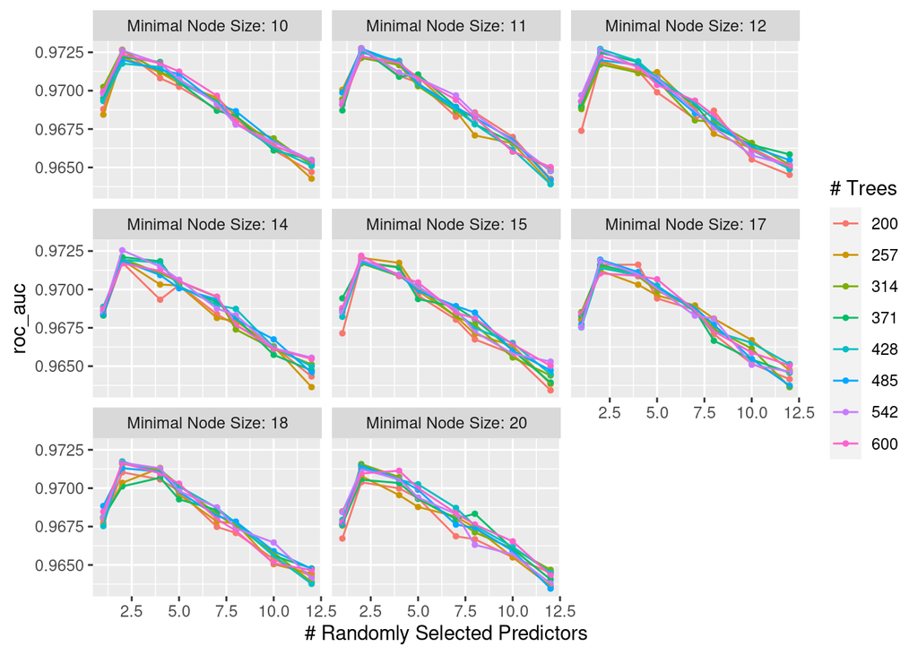

```r
autoplot(rf_tune, metric = 'roc_auc')
```

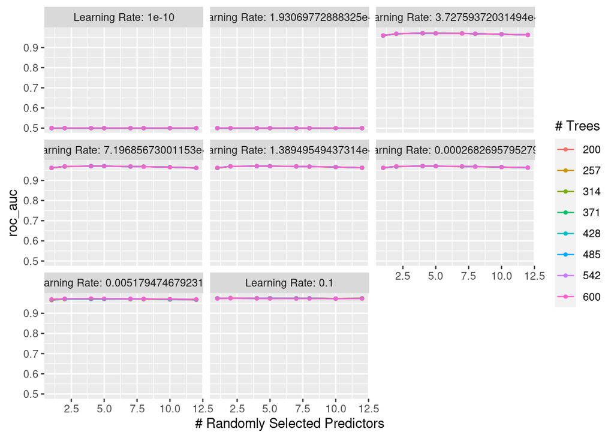

```r
autoplot(bt_tune, metric = 'roc_auc')
```

Most of the parameters in our boosted tree model have more subtle effects with the exception of learning rate, there was a drastic jump in ROC_AUC from graph 2 to graph 3.

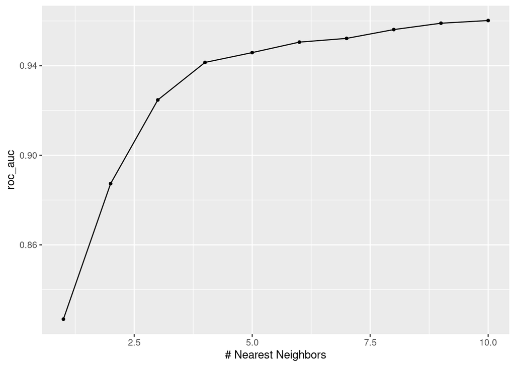

```r
autoplot(knn_tune, metric = 'roc_auc')
```

It looks like a greater number of neighbors for this model resulted in a higher ROC_AUC although there were diminishing returns for values greater than 4 neighbors. I was surprised that this model performed so well considering that we had a pretty large set of predictors.

### Model Comparison

Now lets take a closer look at the ROC_AUC scores for each of the models. Below I’ve constructed a tibble that has the highest ROC_AUC value for each of the models.

```r
en_tune_results = collect_metrics(en_tune, metric = "roc_auc") %>%
                  arrange(mean) %>%
                  tail(n = 1)

rf_tune_results = collect_metrics(rf_tune, metric = "roc_auc") %>%
                  arrange(mean) %>%
                  tail(n = 1)

bt_tune_results = collect_metrics(bt_tune, metric = "roc_auc") %>%
                  arrange(mean) %>%
                  tail(n = 1)

knn_tune_results = collect_metrics(knn_tune, metric = "roc_auc") %>%
                   arrange(mean) %>%
                   tail(n = 1)

svm_tune_results = collect_metrics(svm_tune, metric = "roc_auc") %>%
                   arrange(mean) %>%
                   tail(n = 1)

model_comparison_tibble = tibble(Model = c("Elastic Net", "Random Forest", "Boosted Trees", "K-Nearest Neighbors", "Support Vector Machine"),
                                 ROC_AUC = c(en_tune_results$mean, rf_tune_results$mean, bt_tune_results$mean, knn_tune_results$mean, svm_tune_results$mean))

model_comparison_tibble
```

| Model | ROC_AUC |
| --- | --- |
| Elastic Net | 0.8536986 |
| Random Forest | 0.9727720 |
| Boosted Trees | 0.9760495 |
| K-Nearest Neighbors | 0.9601888 |
| Support Vector Machine | 0.8844791 |

Also included below are the same results in a visual format

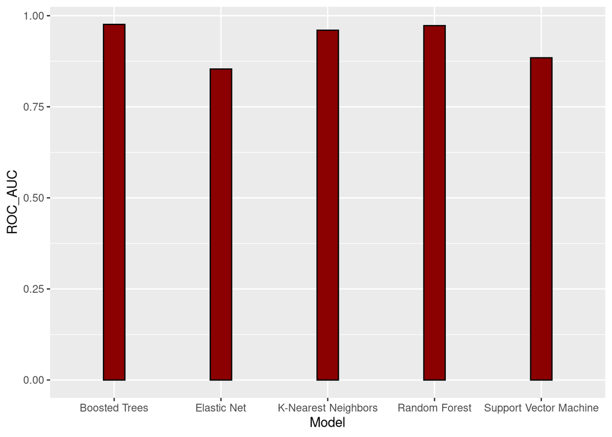

```r
pitch_model_barplot = ggplot(model_comparison_tibble, aes(x = Model, y = ROC_AUC)) +
                      geom_bar(stat = "identity", width = 0.2, fill = 'darkred', color = 'black')

pitch_model_barplot
```

Overall it looks like every single one of our models did a pretty good job! There are two standouts though and those are the boosted tree and random forest models, with the boosted trees model sneaking just past with a slightly higher `roc_auc` value. Let’s take a closer look at the boosted tree.

## Results From Our Best Model

### Performance on the folds

We know that the boosted trees model performed the best, now let’s take a look at the tuned parameters to see which ones were chosen.

```r
show_best(bt_tune, n = 1)
```

| mtry | trees | learn_rate | .metric | .estimator | mean | n | std_err | .config |
| --- | --- | --- | --- | --- | --- | --- | --- | --- |
| 2 | 200 | 0.1 | roc_auc | hand_till | 0.9760495 | 10 | 0.001680898 | Preprocessor1_Model121 |

It looks like boosted trees #121 came out on top with `mtry` = 2, `trees` = 200 and `learn_rate` = 0.1 came out on top with an ROC_AUC score of 0.97!

### Fitting on Testing Data

Now that we’ve narrowed our results down to one model lets fit it to the training data one last time and then evaluate it on the testing sample!

```r
best_pitch_bt = select_best(bt_tune)

final_bt_model = finalize_workflow(pitch_boosted_workflow, best_pitch_bt)
final_bt_model = fit(final_bt_model, pitch_train)

final_bt_model_test = augment(final_bt_model, pitch_test) %>%
                      select(pitch_type, starts_with(".pred"))

roc_auc(final_bt_model_test, truth = pitch_type, .pred_CH:.pred_SL)
```

| .metric | .estimator | .estimate |
| --- | --- | --- |
| roc_auc | hand_till | 0.9653826 |

It’s important to remember that ROC_AUC range from 0 to 1 so a value of 0.96 on our testing data is exceptional!

### Visualizing Performance

Last but not least, let’s take a look a few graphs that will gives us some idea of how well the model was able to classify each level of the outcome variable.

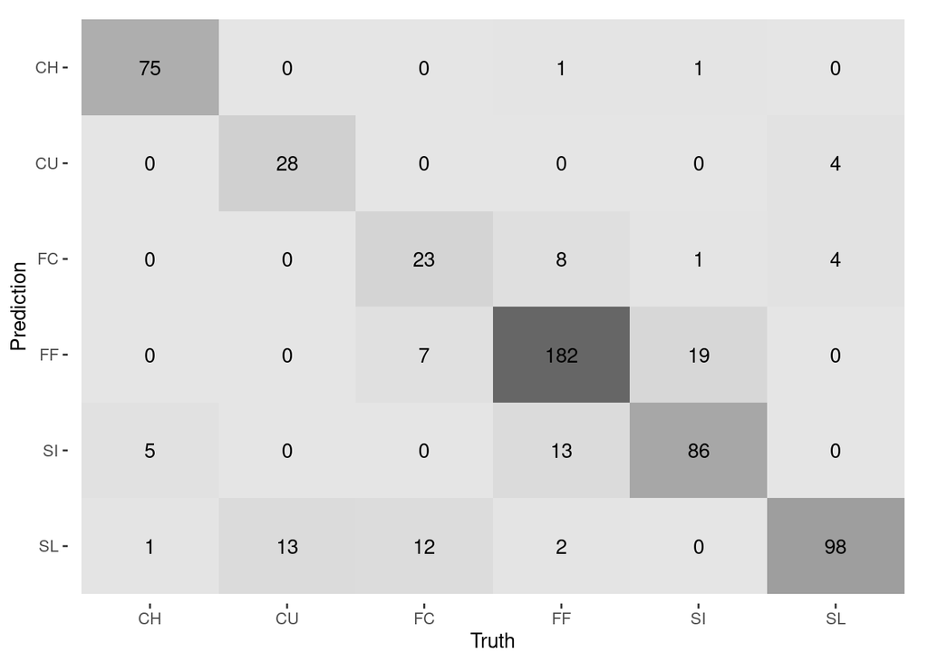

```r
conf_mat(final_bt_model_test, truth = pitch_type, .pred_class) %>%
  autoplot(type = "heatmap")
```

The first graph is a Truth vs Prediction heat map it looks like it guessed FF correctly the most amount of times, which is not very surprising considering that there were more fastballs in the data than any other pitch. However it looks like in terms of accuracy the model performed best on changeups.

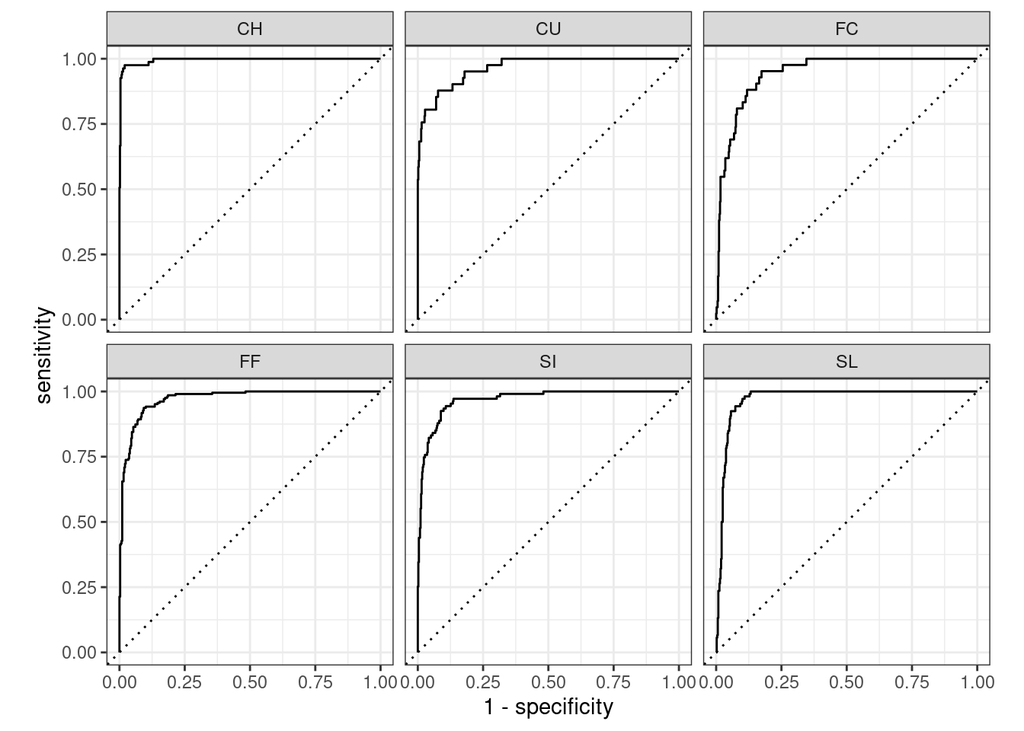

```r
roc_curve(final_bt_model_test, truth = pitch_type, .pred_CH:.pred_SL) %>% autoplot()
```

I also plotted the ROC curves and just as we suspected from the heatmap, the model was best as classifying changeups.

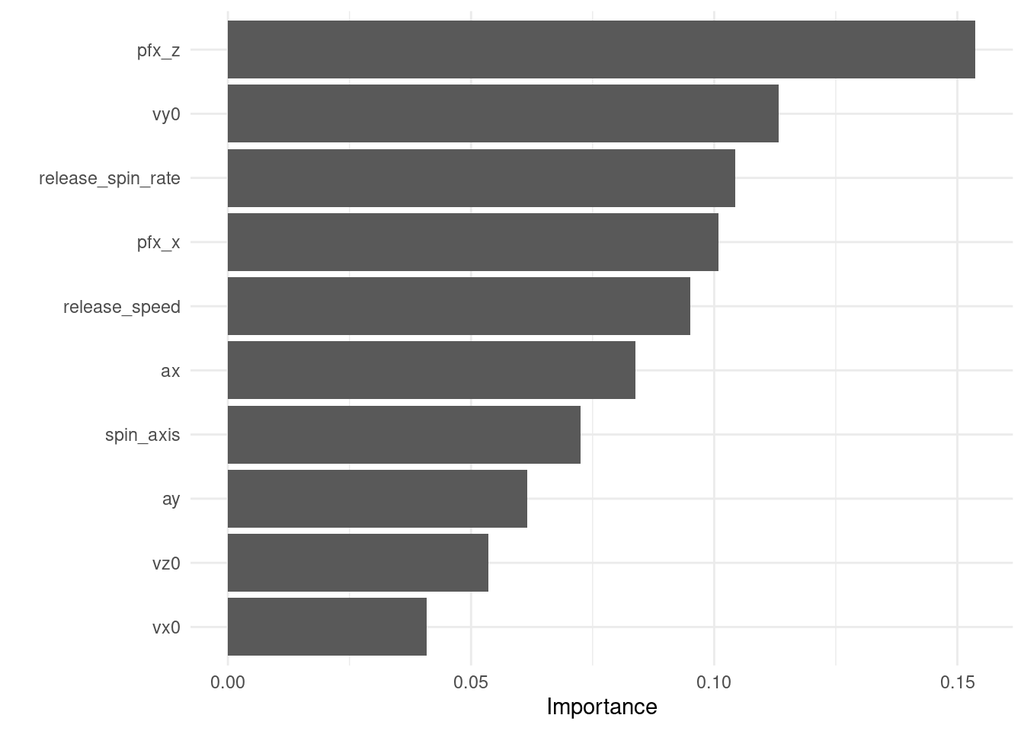

```r
final_bt_model %>% extract_fit_parsnip() %>% vip() + theme_minimal()
```

Let’s take a look at one last visual, we’re almost at the finish line! I wasn’t too surprised by the variables that were most important with the exception of spin axis, based on our preliminary exploratory analysis I thought it would be much higher in terms of importance but nonetheless our models still performed above and beyond my expectations.

## Conclusion

After fitting various models and running them through a tuning process, we landed on a boosted trees model as the best one for classifying pitch types. It comes as no particular surprise considering that it is a nonparametric model and therefore extremely flexible. The model that did the worst was Elastic Net Regression and I suspect that this is because it is simply an extension of logistic regression (which is used for binary classification) so it takes a One vs All approach when it is used for multi-class classification which is not the most efficient.

One avenue that I am definitely going to look into for improvement is extending my repotoire of classification metrics. ROC_AUC is typically used for binary classification, but it can be extended for multiple classes. However, it takes a One vs All approach and so finding a more suitable metric for this type of classification is something I am interested in researching and applying to this project. Along these lines, moving forward I would also be interested in the use of neural networks to apply machine learning models to images. I suspect that despite being more technically challenging the results would be even more accurate, each pitch type requires a certain grip on the ball which is actually fairly easy to recognize (it’s how the Astros were able to win the 2017 World Series after all!).

Overall attempting to predict pitch types was an awesome learning experience and gave me a change to apply all of what I learned in class to a topic I’m very passionate about.